# Intro to Visualization: Gapminder

Let's check out the gapminder data. We'll take log-transformations of GDP and population, since we care more about relative rather than absolute differences in these quantities.

```python
import pandas as pd
import seaborn as sns
import numpy as np

gapminder = pd.read_csv("https://raw.githubusercontent.com/OHI-Science/data-science-training/master/data/gapminder.csv")
gapminder = gapminder.assign(
  log_gdp=lambda df: np.log(df["gdpPercap"]),
  log_pop=lambda df: np.log(df["pop"]),
  decade=lambda df: np.floor(df["year"] / 10) * 10
)
gapminder
```

|  | country | year | pop | continent | lifeExp | gdpPercap | log_gdp | log_pop | decade |
| --- | --- | --- | --- | --- | --- | --- | --- | --- | --- |
| 0 | Afghanistan | 1952 | 8425333.0 | Asia | 28.801 | 779.445314 | 6.658583 | 15.946754 | 1950.0 |
| 1 | Afghanistan | 1957 | 9240934.0 | Asia | 30.332 | 820.853030 | 6.710344 | 16.039154 | 1950.0 |
| 2 | Afghanistan | 1962 | 10267083.0 | Asia | 31.997 | 853.100710 | 6.748878 | 16.144454 | 1960.0 |
| 3 | Afghanistan | 1967 | 11537966.0 | Asia | 34.020 | 836.197138 | 6.728864 | 16.261154 | 1960.0 |
| 4 | Afghanistan | 1972 | 13079460.0 | Asia | 36.088 | 739.981106 | 6.606625 | 16.386554 | 1970.0 |
| ... | ... | ... | ... | ... | ... | ... | ... | ... | ... |
| 1699 | Zimbabwe | 1987 | 9216418.0 | Africa | 62.351 | 706.157306 | 6.559838 | 16.036497 | 1980.0 |
| 1700 | Zimbabwe | 1992 | 10704340.0 | Africa | 60.377 | 693.420786 | 6.541637 | 16.186160 | 1990.0 |
| 1701 | Zimbabwe | 1997 | 11404948.0 | Africa | 46.809 | 792.449960 | 6.675129 | 16.249558 | 1990.0 |
| 1702 | Zimbabwe | 2002 | 11926563.0 | Africa | 39.989 | 672.038623 | 6.510316 | 16.294279 | 2000.0 |
| 1703 | Zimbabwe | 2007 | 12311143.0 | Africa | 43.487 | 469.709298 | 6.152114 | 16.326015 | 2000.0 |

1704 rows × 9 columns

Let's focus on just one year (2002), to make these initial plots a bit easier to understand.

```python
gapminder_sub = gapminder.loc[gapminder["year"] == 2002]
gapminder_sub
```

[output not shown]

One question we can ask is, how is GDP related to life expectancy?

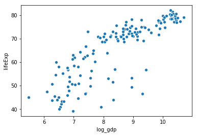

```python
sns.scatterplot(x="log_gdp", y="lifeExp", data=gapminder_sub)
```

How is population related? One answer is to encode population with the size of the points.

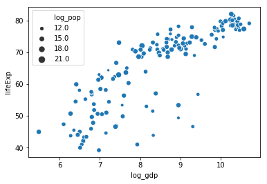

```python
sns.scatterplot(x="log_gdp", y="lifeExp", size="log_pop", data=gapminder_sub)
```

Each point here is a country. On what continents are these countries?

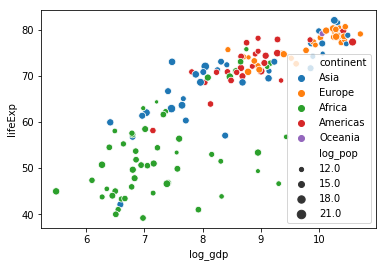

```python
sns.scatterplot(
    x="log_gdp",
    y="lifeExp",
    size="log_pop",
    hue="continent",
    data=gapminder_sub
)
```

It can sometimes be easier to understand variation across groups by explicitly separating them into different panels.

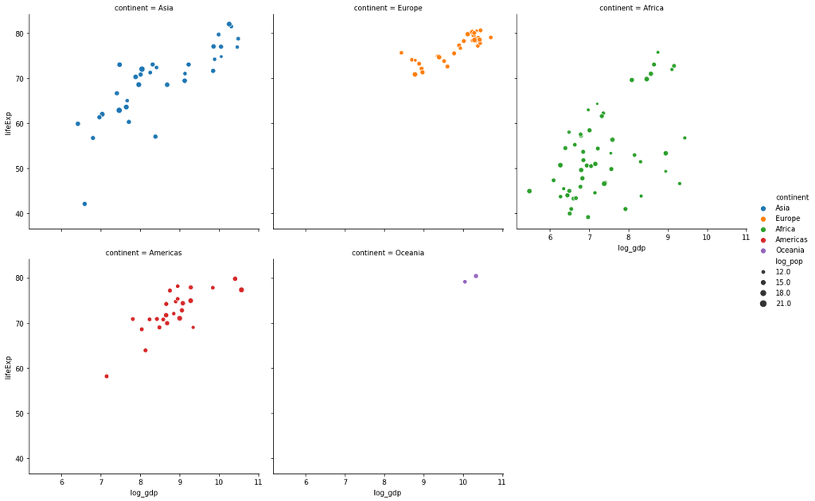

```python
sns.relplot(
    x="log_gdp",
    y="lifeExp",
    size="log_pop",
    hue="continent",
    col="continent",
    col_wrap=3,
    data=gapminder_sub
)
```

Let's make a plot of an ordinal (country) against a continuous (population) variable.

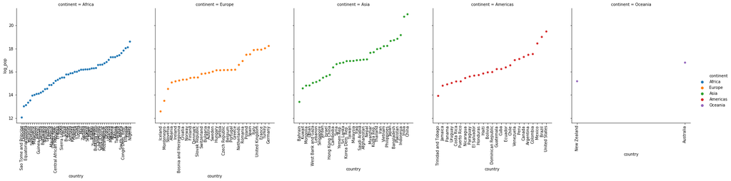

```python
gapminder_sub = gapminder_sub.sort_values("log_pop") # <-- sorts the countries
plot = sns.relplot(
  x="country",
  y="log_pop",
  col="continent",
  hue="continent",
  facet_kws={"sharex": False},
  data=gapminder_sub
)

for ax in plot.axes.flat:
    for label in ax.get_xticklabels():
        label.set_rotation(90)
```

Just for fun, how did populations change over time?

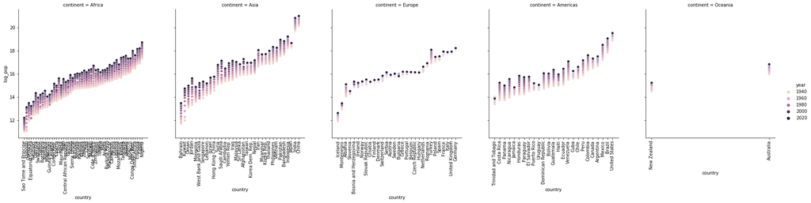

```python
gapminder = gapminder.sort_values(["year", "log_pop"]) # <-- sorts the countries
plot = sns.relplot(
    x="country",
    y="log_pop",
    col="continent",
    hue="year",
    facet_kws={"sharex": False},
    data=gapminder
)

for ax in plot.axes.flat:
    for label in ax.get_xticklabels():
        label.set_rotation(90)
```

So far, we've been looking at the original datapoints, mostly filtered down to one year. Now that we're looking at all the timepoints, we see that it might be useful to reduce raw points to distributional summaries. Let's look at a histogram of the log GDP.

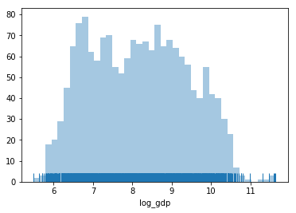

```python
sns.distplot(gapminder["log_gdp"], rug=True, kde=False, bins=40)
```

Histograms count how many samples fall into a bin along one axis. The corresponding plot in two dimensions is called a "hexbin" plot.

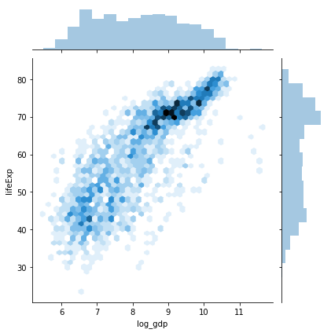

```python
sns.jointplot(x="log_gdp", y="lifeExp", data=gapminder, kind="hex", joint_kws={"gridsize": 40})
```

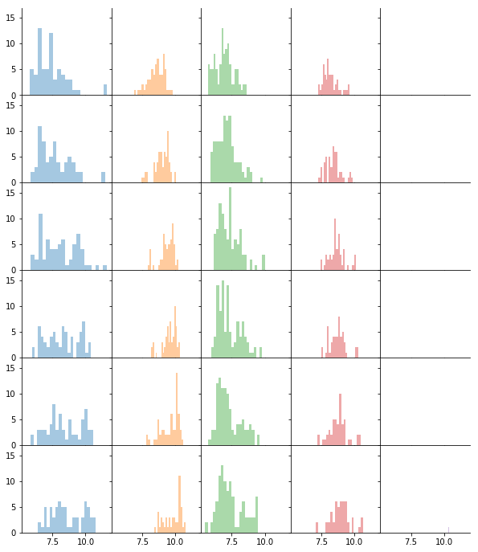

```python
plot = sns.FacetGrid(gapminder, col="continent", hue="continent", row="decade", height=2, gridspec_kws={"hspace": 0.01, "wspace":0.0})
plot = plot.map(sns.distplot, "log_gdp", bins=20, kde=False)
plot.set_titles("")
plot.set_axis_labels("")
```

This has some interesting information, but is extremely unwieldy (the mostly empty column for Oceania is especially irritating). Let's see how a violin plot can communicate the same information much more succinctly.

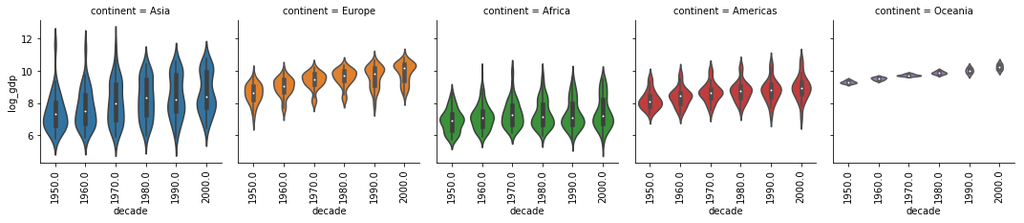

```python
plot = sns.FacetGrid(gapminder, col="continent", hue="continent")
plot = plot.map(sns.violinplot, "decade", "log_gdp")

for ax in plot.axes.flat:
    for label in ax.get_xticklabels():
        label.set_rotation(90)
```